# COVID-19 Data Analysis and Visualization - India

```python
import pandas as pd
import numpy as np
import matplotlib.pyplot as plt
import seaborn as sns
import plotly.express as px
from plotly.subplots import make_subplots
from datetime import datetime
```

```python
covid_df = pd.read_csv("covid_19_india.csv")
```

```python
covid_df.head(10)
```

|  | Sno | Date | Time | State/UnionTerritory | ConfirmedIndianNational | ConfirmedForeignNational | Cured | Deaths | Confirmed |
| --- | --- | --- | --- | --- | --- | --- | --- | --- | --- |
| 0 | 1.0 | 2020-01-30 | 6:00 PM | Kerala | 1 | 0 | 0.0 | 0.0 | 1.0 |
| 1 | 2.0 | 2020-01-31 | 6:00 PM | Kerala | 1 | 0 | 0.0 | 0.0 | 1.0 |
| 2 | 3.0 | 2020-02-01 | 6:00 PM | Kerala | 2 | 0 | 0.0 | 0.0 | 2.0 |
| 3 | 4.0 | 2020-02-02 | 6:00 PM | Kerala | 3 | 0 | 0.0 | 0.0 | 3.0 |
| 4 | 5.0 | 2020-02-03 | 6:00 PM | Kerala | 3 | 0 | 0.0 | 0.0 | 3.0 |
| 5 | 6.0 | 2020-02-04 | 6:00 PM | Kerala | 3 | 0 | 0.0 | 0.0 | 3.0 |
| 6 | 7.0 | 2020-02-05 | 6:00 PM | Kerala | 3 | 0 | 0.0 | 0.0 | 3.0 |
| 7 | 8.0 | 2020-02-06 | 6:00 PM | Kerala | 3 | 0 | 0.0 | 0.0 | 3.0 |
| 8 | 9.0 | 2020-02-07 | 6:00 PM | Kerala | 3 | 0 | 0.0 | 0.0 | 3.0 |
| 9 | 10.0 | 2020-02-08 | 6:00 PM | Kerala | 3 | 0 | 0.0 | 0.0 | 3.0 |

```python
covid_df.info()
```

```
<class 'pandas.core.frame.DataFrame'>
RangeIndex: 15114 entries, 0 to 15113
Data columns (total 9 columns):
 #   Column                    Non-Null Count  Dtype
---  ------                    --------------  -----
 0   Sno                       15086 non-null  float64
 1   Date                      15086 non-null  object
 2   Time                      15086 non-null  object
 3   State/UnionTerritory      15086 non-null  object
 4   ConfirmedIndianNational   15086 non-null  object
 5   ConfirmedForeignNational  15086 non-null  object
 6   Cured                     15086 non-null  float64
 7   Deaths                    15086 non-null  float64
 8   Confirmed                 15086 non-null  float64
dtypes: float64(4), object(5)
memory usage: 1.0+ MB
```

```python
covid_df.describe()
```

|  | Sno | Cured | Deaths | Confirmed |
| --- | --- | --- | --- | --- |
| count | 15086.000000 | 1.508600e+04 | 15086.000000 | 1.508600e+04 |
| mean | 7543.500000 | 1.747937e+05 | 2721.084449 | 1.942820e+05 |
| std | 4355.097416 | 3.648330e+05 | 7182.672358 | 4.095184e+05 |
| min | 1.000000 | 0.000000e+00 | 0.000000 | 0.000000e+00 |
| 25% | 3772.250000 | 1.685000e+03 | 12.000000 | 2.935500e+03 |
| 50% | 7543.500000 | 1.964700e+04 | 364.000000 | 2.608150e+04 |
| 75% | 11314.750000 | 2.087552e+05 | 2170.000000 | 2.216012e+05 |
| max | 15086.000000 | 4.927480e+06 | 83777.000000 | 5.433506e+06 |

```python
vaccine_df = pd.read_csv("covid_vaccine_statewise.csv")
```

```python
vaccine_df.head(10)
```

|  | Updated On | State | Total Doses Administered | Sessions | Sites | First Dose Administered | Second Dose Administered | Male (Doses Administered) | Female (Doses Administered) | Transgender (Doses Administered) | ... | 18-44 Years (Doses Administered) | 45-60 Years (Doses Administered) | 60+ Years (Doses Administered) | 18-44 Years(Individuals Vaccinated) | 45-60 Years(Individuals Vaccinated) | 60+ Years(Individuals Vaccinated) | Male(Individuals Vaccinated) | Female(Individuals Vaccinated) | Transgender(Individuals Vaccinated) | Total Individuals Vaccinated |
| --- | --- | --- | --- | --- | --- | --- | --- | --- | --- | --- | --- | --- | --- | --- | --- | --- | --- | --- | --- | --- | --- |
| 0 | 16/01/2021 | India | 48276.0 | 3455.0 | 2957.0 | 48276.0 | 0.0 | NaN | NaN | NaN | ... | NaN | NaN | NaN | NaN | NaN | NaN | 23757.0 | 24517.0 | 2.0 | 48276.0 |
| 1 | 17/01/2021 | India | 58604.0 | 8532.0 | 4954.0 | 58604.0 | 0.0 | NaN | NaN | NaN | ... | NaN | NaN | NaN | NaN | NaN | NaN | 27348.0 | 31252.0 | 4.0 | 58604.0 |
| 2 | 18/01/2021 | India | 99449.0 | 13611.0 | 6583.0 | 99449.0 | 0.0 | NaN | NaN | NaN | ... | NaN | NaN | NaN | NaN | NaN | NaN | 41361.0 | 58083.0 | 5.0 | 99449.0 |
| 3 | 19/01/2021 | India | 195525.0 | 17855.0 | 7951.0 | 195525.0 | 0.0 | NaN | NaN | NaN | ... | NaN | NaN | NaN | NaN | NaN | NaN | 81901.0 | 113613.0 | 11.0 | 195525.0 |
| 4 | 20/01/2021 | India | 251280.0 | 25472.0 | 10504.0 | 251280.0 | 0.0 | NaN | NaN | NaN | ... | NaN | NaN | NaN | NaN | NaN | NaN | 98111.0 | 153145.0 | 24.0 | 251280.0 |
| 5 | 21/01/2021 | India | 365965.0 | 32226.0 | 12600.0 | 365965.0 | 0.0 | NaN | NaN | NaN | ... | NaN | NaN | NaN | NaN | NaN | NaN | 132784.0 | 233143.0 | 38.0 | 365965.0 |
| 6 | 22/01/2021 | India | 549381.0 | 36988.0 | 14115.0 | 549381.0 | 0.0 | NaN | NaN | NaN | ... | NaN | NaN | NaN | NaN | NaN | NaN | 193899.0 | 355402.0 | 80.0 | 549381.0 |
| 7 | 23/01/2021 | India | 759008.0 | 43076.0 | 15605.0 | 759008.0 | 0.0 | NaN | NaN | NaN | ... | NaN | NaN | NaN | NaN | NaN | NaN | 267856.0 | 491049.0 | 103.0 | 759008.0 |
| 8 | 24/01/2021 | India | 835058.0 | 49851.0 | 18111.0 | 835058.0 | 0.0 | NaN | NaN | NaN | ... | NaN | NaN | NaN | NaN | NaN | NaN | 296283.0 | 538647.0 | 128.0 | 835058.0 |
| 9 | 25/01/2021 | India | 1277104.0 | 55151.0 | 19682.0 | 1277104.0 | 0.0 | NaN | NaN | NaN | ... | NaN | NaN | NaN | NaN | NaN | NaN | 444137.0 | 832766.0 | 201.0 | 1277104.0 |

10 rows × 24 columns

```python
covid_df.drop(['Sno', 'Time', 'ConfirmedIndianNational', 'ConfirmedForeignNational'], inplace = True, axis = 1)
```

```python
covid_df.head()
```

|  | Date | State/UnionTerritory | Cured | Deaths | Confirmed |
| --- | --- | --- | --- | --- | --- |
| 0 | 2020-01-30 | Kerala | 0.0 | 0.0 | 1.0 |
| 1 | 2020-01-31 | Kerala | 0.0 | 0.0 | 1.0 |
| 2 | 2020-02-01 | Kerala | 0.0 | 0.0 | 2.0 |
| 3 | 2020-02-02 | Kerala | 0.0 | 0.0 | 3.0 |
| 4 | 2020-02-03 | Kerala | 0.0 | 0.0 | 3.0 |

```python
covid_df['Date'] = pd.to_datetime(covid_df['Date'], format = '%Y-%m-%d')
```

```python
covid_df.head()
```

|  | Date | State/UnionTerritory | Cured | Deaths | Confirmed |
| --- | --- | --- | --- | --- | --- |
| 0 | 2020-01-30 | Kerala | 0.0 | 0.0 | 1.0 |
| 1 | 2020-01-31 | Kerala | 0.0 | 0.0 | 1.0 |
| 2 | 2020-02-01 | Kerala | 0.0 | 0.0 | 2.0 |
| 3 | 2020-02-02 | Kerala | 0.0 | 0.0 | 3.0 |
| 4 | 2020-02-03 | Kerala | 0.0 | 0.0 | 3.0 |

```python
# Active Cases
covid_df['Active_Cases'] = (covid_df['Confirmed'] - covid_df['Cured'] + covid_df['Deaths'])
```

```python
# Drop rows where 'Date' or 'State/UnionTerritory' is NaN as Nan values exist in the dataset
covid_df = covid_df.dropna(subset=['Date', 'State/UnionTerritory'])

# Reset index after dropping
covid_df.reset_index(drop=True, inplace=True)
covid_df.tail(10)
```

|  | Date | State/UnionTerritory | Cured | Deaths | Confirmed | Active_Cases |
| --- | --- | --- | --- | --- | --- | --- |
| 15076 | 2021-05-19 | Puducherry | 69060.0 | 1212.0 | 87749.0 | 19901.0 |
| 15077 | 2021-05-19 | Punjab | 427058.0 | 12317.0 | 511652.0 | 96911.0 |
| 15078 | 2021-05-19 | Rajasthan | 713129.0 | 7080.0 | 879664.0 | 173615.0 |
| 15079 | 2021-05-19 | Sikkim | 8427.0 | 212.0 | 11689.0 | 3474.0 |
| 15080 | 2021-05-19 | Tamil Nadu | 1403052.0 | 18369.0 | 1664350.0 | 279667.0 |
| 15081 | 2021-05-19 | Telangana | 485644.0 | 3012.0 | 536766.0 | 54134.0 |
| 15082 | 2021-05-19 | Tripura | 36402.0 | 450.0 | 42776.0 | 6824.0 |
| 15083 | 2021-05-19 | Uttarakhand | 214426.0 | 5132.0 | 295790.0 | 86496.0 |
| 15084 | 2021-05-19 | Uttar Pradesh | 1483249.0 | 18072.0 | 1637663.0 | 172486.0 |
| 15085 | 2021-05-19 | West Bengal | 1026492.0 | 13576.0 | 1171861.0 | 158945.0 |

```python
# List of columns to convert
cols_to_convert = ['Cured', 'Deaths', 'Confirmed', 'Active_Cases']

# Convert to integer type
covid_df[cols_to_convert] = covid_df[cols_to_convert].astype('Int64')  # Use 'Int64' to allow for NA values
covid_df.tail(10)
```

|  | Date | State/UnionTerritory | Cured | Deaths | Confirmed | Active_Cases |
| --- | --- | --- | --- | --- | --- | --- |
| 15076 | 2021-05-19 | Puducherry | 69060 | 1212 | 87749 | 19901 |
| 15077 | 2021-05-19 | Punjab | 427058 | 12317 | 511652 | 96911 |
| 15078 | 2021-05-19 | Rajasthan | 713129 | 7080 | 879664 | 173615 |
| 15079 | 2021-05-19 | Sikkim | 8427 | 212 | 11689 | 3474 |
| 15080 | 2021-05-19 | Tamil Nadu | 1403052 | 18369 | 1664350 | 279667 |
| 15081 | 2021-05-19 | Telangana | 485644 | 3012 | 536766 | 54134 |
| 15082 | 2021-05-19 | Tripura | 36402 | 450 | 42776 | 6824 |
| 15083 | 2021-05-19 | Uttarakhand | 214426 | 5132 | 295790 | 86496 |
| 15084 | 2021-05-19 | Uttar Pradesh | 1483249 | 18072 | 1637663 | 172486 |
| 15085 | 2021-05-19 | West Bengal | 1026492 | 13576 | 1171861 | 158945 |

### How do states compare in terms of confirmed cases, recovery rate, and mortality rate?

```python
statewise = pd.pivot_table(covid_df, values = ['Confirmed', 'Deaths', 'Cured'],
                           index = 'State/UnionTerritory', aggfunc = 'max')
```

```python
statewise['Recovery Rate'] = statewise['Cured']*100/statewise['Confirmed']
```

```python
statewise['Mortality Rate'] = statewise['Deaths']*100/statewise['Confirmed']
```

```python
statewise = statewise.sort_values(by = 'Confirmed', ascending = False)
```

```python
statewise.style.background_gradient(cmap = 'cubehelix')
```

| State/UnionTerritory | Confirmed | Cured | Deaths | Recovery Rate | Mortality Rate |
| --- | --- | --- | --- | --- | --- |
| Maharashtra | 5433506 | 4927480 | 83777 | 90.686934 | 1.541859 |
| Karnataka | 2272374 | 1674487 | 22838 | 73.688882 | 1.005028 |
| Kerala | 2200706 | 1846105 | 6612 | 83.886944 | 0.300449 |
| Tamil Nadu | 1664350 | 1403052 | 18369 | 84.300297 | 1.103674 |
| Uttar Pradesh | 1637663 | 1483249 | 18072 | 90.571076 | 1.103524 |
| Andhra Pradesh | 1475372 | 1254291 | 9580 | 85.015237 | 0.649328 |
| Delhi | 1402873 | 1329899 | 22111 | 94.798246 | 1.576123 |
| West Bengal | 1171861 | 1026492 | 13576 | 87.595030 | 1.158499 |
| Chhattisgarh | 925531 | 823113 | 12036 | 88.934136 | 1.300443 |
| Rajasthan | 879664 | 713129 | 7080 | 81.068340 | 0.804853 |
| Gujarat | 766201 | 660489 | 9269 | 86.203098 | 1.209735 |
| Madhya Pradesh | 742718 | 652612 | 7139 | 87.868074 | 0.961199 |
| Haryana | 709689 | 626852 | 6923 | 88.327704 | 0.975498 |
| Bihar | 664115 | 595377 | 4039 | 89.649684 | 0.608178 |
| Odisha | 633302 | 536595 | 2357 | 84.729718 | 0.372176 |
| Telangana | 536766 | 485644 | 3012 | 90.475924 | 0.561138 |
| Punjab | 511652 | 427058 | 12317 | 83.466497 | 2.407300 |
| Telengana | 443360 | 362160 | 2312 | 81.685312 | 0.521472 |
| Assam | 340858 | 290774 | 2344 | 85.306491 | 0.687676 |
| Jharkhand | 320934 | 284805 | 4601 | 88.742545 | 1.433628 |
| Uttarakhand | 295790 | 214426 | 5132 | 72.492647 | 1.735015 |
| Jammu and Kashmir | 251919 | 197701 | 3293 | 78.478003 | 1.307166 |
| Himachal Pradesh | 166678 | 129330 | 2460 | 77.592724 | 1.475900 |
| Goa | 138776 | 112633 | 2197 | 81.161728 | 1.583127 |
| Puducherry | 87749 | 69060 | 1212 | 78.701752 | 1.381212 |
| Chandigarh | 56513 | 48831 | 647 | 86.406667 | 1.144869 |
| Tripura | 42776 | 36402 | 450 | 85.099121 | 1.051992 |
| Manipur | 40683 | 33466 | 612 | 82.260404 | 1.504314 |
| Meghalaya | 24872 | 19185 | 355 | 77.134931 | 1.427308 |
| Arunachal Pradesh | 22462 | 19977 | 88 | 88.936871 | 0.391773 |
| Nagaland | 18714 | 14079 | 228 | 75.232446 | 1.218339 |
| Ladakh | 16784 | 15031 | 170 | 89.555529 | 1.012869 |
| Sikkim | 11689 | 8427 | 212 | 72.093421 | 1.813671 |
| Dadra and Nagar Haveli and Daman and Diu | 9652 | 8944 | 4 | 92.664733 | 0.041442 |
| Cases being reassigned to states | 9265 | 0 | 0 | 0.000000 | 0.000000 |
| Mizoram | 9252 | 7094 | 29 | 76.675313 | 0.313446 |
| Andaman and Nicobar Islands | 6674 | 6359 | 92 | 95.280192 | 1.378484 |
| Lakshadweep | 5212 | 3915 | 15 | 75.115119 | 0.287797 |
| Unassigned | 77 | 0 | 0 | 0.000000 | 0.000000 |
| Daman & Diu | 2 | 0 | 0 | 0.000000 | 0.000000 |

### Which states in India have the highest number of active COVID-19 cases?

```python
# Top 10 active cases states

top10_active_cases = covid_df.groupby(by = 'State/UnionTerritory').max()[['Active_Cases', 'Date']].sort_values(by = ['Active_Cases'], ascending = False).reset_index()
```

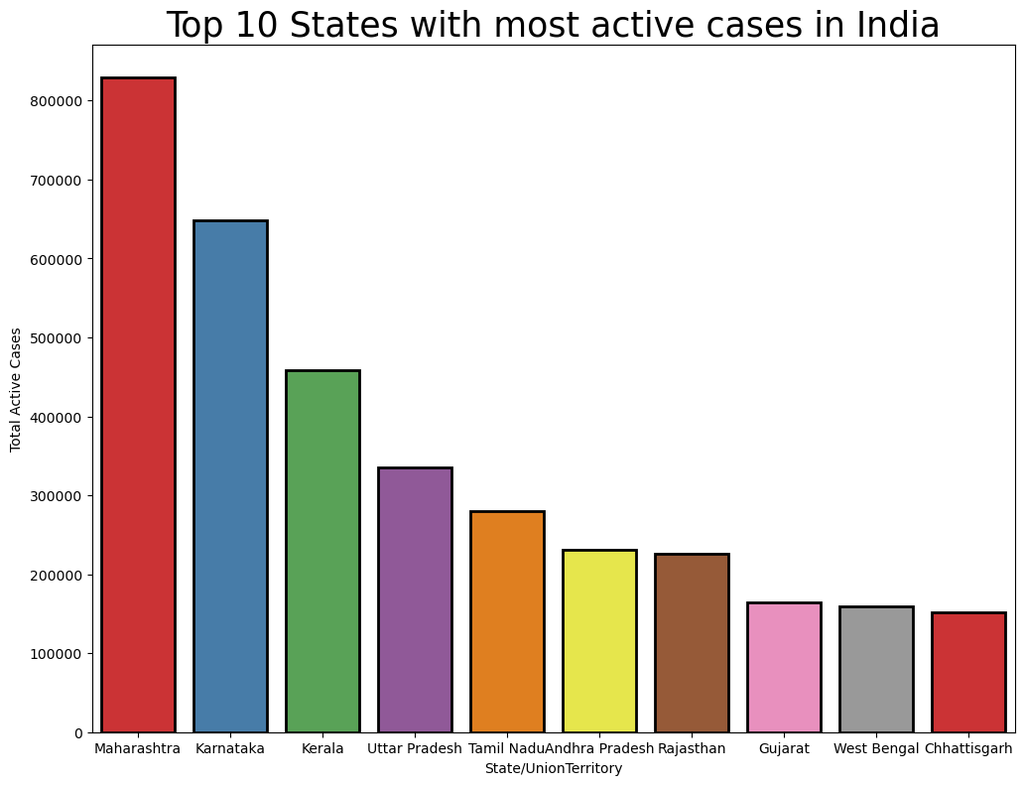

```python
fig = plt.figure(figsize = (12,9))
plt.title('Top 10 States with most active cases in India', size = 25)
ax = sns.barplot(data = top10_active_cases.iloc[:10],
                 y = 'Active_Cases', x = 'State/UnionTerritory', hue = 'State/UnionTerritory',
                 linewidth = 2, edgecolor = 'black', palette = 'Set1')
plt.xlabel('State/UnionTerritory')
plt.ylabel('Total Active Cases')
plt.show()
```

### Which states in India have reported the highest number of COVID-19 deaths?

[figure not shown]

```python
# Top states with highest deaths

top10_deaths = covid_df.groupby(by = 'State/UnionTerritory').max()[['Deaths', 'Date']].sort_values(by = ['Deaths'], ascending = False).reset_index()

fig1 = plt.figure(figsize = (8,6))
plt.title('Top 10 states with most Deaths', size = 25)
ax = sns.barplot(data = top10_deaths.iloc[:12], y = 'Deaths', x = 'State/UnionTerritory', hue = 'State/UnionTerritory',
                 linewidth = 1.5, edgecolor = 'red', palette = 'Set3')
plt.xlabel('State/UnionTerritory')
plt.ylabel('Total Death Cases')
plt.xticks(rotation = 45)
plt.tight_layout()
plt.show()
```

### Which states had the highest number of active COVID-19 cases as of the most recent date available in the dataset?

```python
# Ensure Date is datetime type
covid_df['Date'] = pd.to_datetime(covid_df['Date'])

# Filter data for the latest date
latest_date = covid_df['Date'].max()
latest_df = covid_df[covid_df['Date'] == latest_date]

# Sort states by Active Cases (descending) and pick top 5
top_5_states = latest_df.sort_values('Active_Cases', ascending=False).head(5)
print(top_5_states[['State/UnionTerritory', 'Active_Cases']])
```

```
      State/UnionTerritory  Active_Cases
15065            Karnataka        620725
15070          Maharashtra        589803
15066               Kerala        361213
15080           Tamil Nadu        279667
15051       Andhra Pradesh        230661
```

```python
# Extract list of top 5 states
top_5_states_list = top_5_states['State/UnionTerritory'].tolist()

# Filter original dataframe for only these states
filtered_df = covid_df[covid_df['State/UnionTerritory'].isin(top_5_states_list)]
filtered_df
```

|  | Date | State/UnionTerritory | Cured | Deaths | Confirmed | Active_Cases |
| --- | --- | --- | --- | --- | --- | --- |
| 0 | 2020-01-30 | Kerala | 0 | 0 | 1 | 1 |
| 1 | 2020-01-31 | Kerala | 0 | 0 | 1 | 1 |
| 2 | 2020-02-01 | Kerala | 0 | 0 | 2 | 2 |
| 3 | 2020-02-02 | Kerala | 0 | 0 | 3 | 3 |
| 4 | 2020-02-03 | Kerala | 0 | 0 | 3 | 3 |
| ... | ... | ... | ... | ... | ... | ... |
| 15051 | 2021-05-19 | Andhra Pradesh | 1254291 | 9580 | 1475372 | 230661 |
| 15065 | 2021-05-19 | Karnataka | 1674487 | 22838 | 2272374 | 620725 |
| 15066 | 2021-05-19 | Kerala | 1846105 | 6612 | 2200706 | 361213 |
| 15070 | 2021-05-19 | Maharashtra | 4927480 | 83777 | 5433506 | 589803 |
| 15080 | 2021-05-19 | Tamil Nadu | 1403052 | 18369 | 1664350 | 279667 |

2223 rows × 6 columns

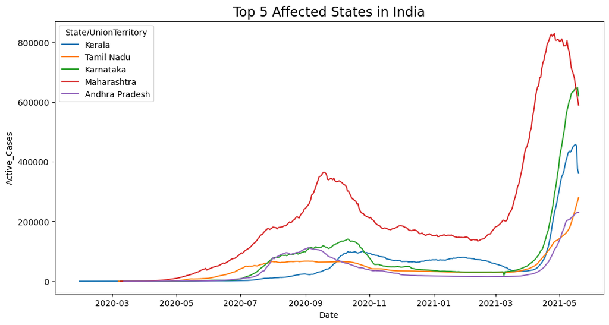

```python
# Growth trend

fig = plt.figure(figsize = (12,6))

ax = sns.lineplot(data = filtered_df,
                  x = 'Date', y = 'Active_Cases', hue = 'State/UnionTerritory')
ax.set_title('Top 5 Affected States in India', size = 16)
```

```python
vaccine_df.head()
```

|  | Updated On | State | Total Doses Administered | Sessions | Sites | First Dose Administered | Second Dose Administered | Male (Doses Administered) | Female (Doses Administered) | Transgender (Doses Administered) | ... | 18-44 Years (Doses Administered) | 45-60 Years (Doses Administered) | 60+ Years (Doses Administered) | 18-44 Years(Individuals Vaccinated) | 45-60 Years(Individuals Vaccinated) | 60+ Years(Individuals Vaccinated) | Male(Individuals Vaccinated) | Female(Individuals Vaccinated) | Transgender(Individuals Vaccinated) | Total Individuals Vaccinated |
| --- | --- | --- | --- | --- | --- | --- | --- | --- | --- | --- | --- | --- | --- | --- | --- | --- | --- | --- | --- | --- | --- |
| 0 | 16/01/2021 | India | 48276.0 | 3455.0 | 2957.0 | 48276.0 | 0.0 | NaN | NaN | NaN | ... | NaN | NaN | NaN | NaN | NaN | NaN | 23757.0 | 24517.0 | 2.0 | 48276.0 |
| 1 | 17/01/2021 | India | 58604.0 | 8532.0 | 4954.0 | 58604.0 | 0.0 | NaN | NaN | NaN | ... | NaN | NaN | NaN | NaN | NaN | NaN | 27348.0 | 31252.0 | 4.0 | 58604.0 |
| 2 | 18/01/2021 | India | 99449.0 | 13611.0 | 6583.0 | 99449.0 | 0.0 | NaN | NaN | NaN | ... | NaN | NaN | NaN | NaN | NaN | NaN | 41361.0 | 58083.0 | 5.0 | 99449.0 |
| 3 | 19/01/2021 | India | 195525.0 | 17855.0 | 7951.0 | 195525.0 | 0.0 | NaN | NaN | NaN | ... | NaN | NaN | NaN | NaN | NaN | NaN | 81901.0 | 113613.0 | 11.0 | 195525.0 |
| 4 | 20/01/2021 | India | 251280.0 | 25472.0 | 10504.0 | 251280.0 | 0.0 | NaN | NaN | NaN | ... | NaN | NaN | NaN | NaN | NaN | NaN | 98111.0 | 153145.0 | 24.0 | 251280.0 |

5 rows × 24 columns

```python
vaccine_df.rename(columns = {'Updated On': 'Vaccination_Date'}, inplace = True)
```

```python
vaccine_df.info()
```

```
<class 'pandas.core.frame.DataFrame'>
RangeIndex: 7845 entries, 0 to 7844
Data columns (total 24 columns):
 #   Column                               Non-Null Count  Dtype
---  ------                               --------------  -----
 0   Vaccination_Date                     7845 non-null   object
 1   State                                7845 non-null   object
 2   Total Doses Administered             7621 non-null   float64
 3   Sessions                             7621 non-null   float64
 4    Sites                               7621 non-null   float64
 5   First Dose Administered              7621 non-null   float64
 6   Second Dose Administered             7621 non-null   float64
 7   Male (Doses Administered)            7461 non-null   float64
 8   Female (Doses Administered)          7461 non-null   float64
 9   Transgender (Doses Administered)     7461 non-null   float64
```

[output cut: 16 more lines]

```python
vaccine_df.isnull().sum()
```

```
Vaccination_Date                          0
State                                     0
Total Doses Administered                224
Sessions                                224
 Sites                                  224
First Dose Administered                 224
Second Dose Administered                224
Male (Doses Administered)               384
Female (Doses Administered)             384
Transgender (Doses Administered)        384
 Covaxin (Doses Administered)           224
CoviShield (Doses Administered)         224
Sputnik V (Doses Administered)         4850
AEFI                                   2407
18-44 Years (Doses Administered)       6143
45-60 Years (Doses Administered)       6143
60+ Years (Doses Administered)         6143
18-44 Years(Individuals Vaccinated)    4112
45-60 Years(Individuals Vaccinated)    4111
60+ Years(Individuals Vaccinated)      4111
Male(Individuals Vaccinated)           7685
Female(Individuals Vaccinated)         7685
Transgender(Individuals Vaccinated)    7685
Total Individuals Vaccinated           1926
dtype: int64
```

```python
vaccination = vaccine_df.drop(columns = ['Sputnik V (Doses Administered)', 'AEFI', '18-44 Years (Doses Administered)',
                                         '45-60 Years (Doses Administered)', '60+ Years (Doses Administered)'], axis = 1)
```

```python
vaccination.head()
```

|  | Vaccination_Date | State | Total Doses Administered | Sessions | Sites | First Dose Administered | Second Dose Administered | Male (Doses Administered) | Female (Doses Administered) | Transgender (Doses Administered) | Covaxin (Doses Administered) | CoviShield (Doses Administered) | 18-44 Years(Individuals Vaccinated) | 45-60 Years(Individuals Vaccinated) | 60+ Years(Individuals Vaccinated) | Male(Individuals Vaccinated) | Female(Individuals Vaccinated) | Transgender(Individuals Vaccinated) | Total Individuals Vaccinated |
| --- | --- | --- | --- | --- | --- | --- | --- | --- | --- | --- | --- | --- | --- | --- | --- | --- | --- | --- | --- |
| 0 | 16/01/2021 | India | 48276.0 | 3455.0 | 2957.0 | 48276.0 | 0.0 | NaN | NaN | NaN | 579.0 | 47697.0 | NaN | NaN | NaN | 23757.0 | 24517.0 | 2.0 | 48276.0 |
| 1 | 17/01/2021 | India | 58604.0 | 8532.0 | 4954.0 | 58604.0 | 0.0 | NaN | NaN | NaN | 635.0 | 57969.0 | NaN | NaN | NaN | 27348.0 | 31252.0 | 4.0 | 58604.0 |
| 2 | 18/01/2021 | India | 99449.0 | 13611.0 | 6583.0 | 99449.0 | 0.0 | NaN | NaN | NaN | 1299.0 | 98150.0 | NaN | NaN | NaN | 41361.0 | 58083.0 | 5.0 | 99449.0 |
| 3 | 19/01/2021 | India | 195525.0 | 17855.0 | 7951.0 | 195525.0 | 0.0 | NaN | NaN | NaN | 3017.0 | 192508.0 | NaN | NaN | NaN | 81901.0 | 113613.0 | 11.0 | 195525.0 |
| 4 | 20/01/2021 | India | 251280.0 | 25472.0 | 10504.0 | 251280.0 | 0.0 | NaN | NaN | NaN | 3946.0 | 247334.0 | NaN | NaN | NaN | 98111.0 | 153145.0 | 24.0 | 251280.0 |

### What is the distribution of COVID-19 vaccinations among males and females?

```python
# Male vs Female vaccination

male = vaccination['Male(Individuals Vaccinated)'].sum()
female = vaccination['Female(Individuals Vaccinated)'].sum()
fig_mf = px.pie(names = ['Male', 'Female'], values = [male, female],
       title = 'Male and Female Vaccination', hole = 0.4)
fig_mf.update_traces(textinfo = 'percent+label+value')
fig_mf.show()
```

[interactive chart not shown]

```python
# remove rows where State = India

vaccine_df = vaccine_df[vaccine_df['State']!= 'India']
vaccine_df
```

|  | Vaccination_Date | State | Total Doses Administered | Sessions | Sites | First Dose Administered | Second Dose Administered | Male (Doses Administered) | Female (Doses Administered) | Transgender (Doses Administered) | ... | 18-44 Years (Doses Administered) | 45-60 Years (Doses Administered) | 60+ Years (Doses Administered) | 18-44 Years(Individuals Vaccinated) | 45-60 Years(Individuals Vaccinated) | 60+ Years(Individuals Vaccinated) | Male(Individuals Vaccinated) | Female(Individuals Vaccinated) | Transgender(Individuals Vaccinated) | Total Individuals Vaccinated |
| --- | --- | --- | --- | --- | --- | --- | --- | --- | --- | --- | --- | --- | --- | --- | --- | --- | --- | --- | --- | --- | --- |
| 212 | 16/01/2021 | Andaman and Nicobar Islands | 23.0 | 2.0 | 2.0 | 23.0 | 0.0 | 12.0 | 11.0 | 0.0 | ... | NaN | NaN | NaN | NaN | NaN | NaN | NaN | NaN | NaN | 23.0 |
| 213 | 17/01/2021 | Andaman and Nicobar Islands | 23.0 | 2.0 | 2.0 | 23.0 | 0.0 | 12.0 | 11.0 | 0.0 | ... | NaN | NaN | NaN | NaN | NaN | NaN | NaN | NaN | NaN | 23.0 |
| 214 | 18/01/2021 | Andaman and Nicobar Islands | 42.0 | 9.0 | 2.0 | 42.0 | 0.0 | 29.0 | 13.0 | 0.0 | ... | NaN | NaN | NaN | NaN | NaN | NaN | NaN | NaN | NaN | 42.0 |
| 215 | 19/01/2021 | Andaman and Nicobar Islands | 89.0 | 12.0 | 2.0 | 89.0 | 0.0 | 53.0 | 36.0 | 0.0 | ... | NaN | NaN | NaN | NaN | NaN | NaN | NaN | NaN | NaN | 89.0 |
| 216 | 20/01/2021 | Andaman and Nicobar Islands | 124.0 | 16.0 | 3.0 | 124.0 | 0.0 | 67.0 | 57.0 | 0.0 | ... | NaN | NaN | NaN | NaN | NaN | NaN | NaN | NaN | NaN | 124.0 |
| ... | ... | ... | ... | ... | ... | ... | ... | ... | ... | ... | ... | ... | ... | ... | ... | ... | ... | ... | ... | ... | ... |
| 7840 | 11/08/2021 | West Bengal | NaN | NaN | NaN | NaN | NaN | NaN | NaN | NaN | ... | NaN | NaN | NaN | NaN | NaN | NaN | NaN | NaN | NaN | NaN |
| 7841 | 12/08/2021 | West Bengal | NaN | NaN | NaN | NaN | NaN | NaN | NaN | NaN | ... | NaN | NaN | NaN | NaN | NaN | NaN | NaN | NaN | NaN | NaN |
| 7842 | 13/08/2021 | West Bengal | NaN | NaN | NaN | NaN | NaN | NaN | NaN | NaN | ... | NaN | NaN | NaN | NaN | NaN | NaN | NaN | NaN | NaN | NaN |
| 7843 | 14/08/2021 | West Bengal | NaN | NaN | NaN | NaN | NaN | NaN | NaN | NaN | ... | NaN | NaN | NaN | NaN | NaN | NaN | NaN | NaN | NaN | NaN |
| 7844 | 15/08/2021 | West Bengal | NaN | NaN | NaN | NaN | NaN | NaN | NaN | NaN | ... | NaN | NaN | NaN | NaN | NaN | NaN | NaN | NaN | NaN | NaN |

7633 rows × 24 columns

```python
vaccine_df.rename(columns = {'Total Individuals Vaccinated': 'Total_Ind_Vacc'}, inplace = True)
vaccine_df
```

|  | Vaccination_Date | State | Total Doses Administered | Sessions | Sites | First Dose Administered | Second Dose Administered | Male (Doses Administered) | Female (Doses Administered) | Transgender (Doses Administered) | ... | 18-44 Years (Doses Administered) | 45-60 Years (Doses Administered) | 60+ Years (Doses Administered) | 18-44 Years(Individuals Vaccinated) | 45-60 Years(Individuals Vaccinated) | 60+ Years(Individuals Vaccinated) | Male(Individuals Vaccinated) | Female(Individuals Vaccinated) | Transgender(Individuals Vaccinated) | Total_Ind_Vacc |
| --- | --- | --- | --- | --- | --- | --- | --- | --- | --- | --- | --- | --- | --- | --- | --- | --- | --- | --- | --- | --- | --- |
| 212 | 16/01/2021 | Andaman and Nicobar Islands | 23.0 | 2.0 | 2.0 | 23.0 | 0.0 | 12.0 | 11.0 | 0.0 | ... | NaN | NaN | NaN | NaN | NaN | NaN | NaN | NaN | NaN | 23.0 |
| 213 | 17/01/2021 | Andaman and Nicobar Islands | 23.0 | 2.0 | 2.0 | 23.0 | 0.0 | 12.0 | 11.0 | 0.0 | ... | NaN | NaN | NaN | NaN | NaN | NaN | NaN | NaN | NaN | 23.0 |
| 214 | 18/01/2021 | Andaman and Nicobar Islands | 42.0 | 9.0 | 2.0 | 42.0 | 0.0 | 29.0 | 13.0 | 0.0 | ... | NaN | NaN | NaN | NaN | NaN | NaN | NaN | NaN | NaN | 42.0 |
| 215 | 19/01/2021 | Andaman and Nicobar Islands | 89.0 | 12.0 | 2.0 | 89.0 | 0.0 | 53.0 | 36.0 | 0.0 | ... | NaN | NaN | NaN | NaN | NaN | NaN | NaN | NaN | NaN | 89.0 |
| 216 | 20/01/2021 | Andaman and Nicobar Islands | 124.0 | 16.0 | 3.0 | 124.0 | 0.0 | 67.0 | 57.0 | 0.0 | ... | NaN | NaN | NaN | NaN | NaN | NaN | NaN | NaN | NaN | 124.0 |
| ... | ... | ... | ... | ... | ... | ... | ... | ... | ... | ... | ... | ... | ... | ... | ... | ... | ... | ... | ... | ... | ... |
| 7840 | 11/08/2021 | West Bengal | NaN | NaN | NaN | NaN | NaN | NaN | NaN | NaN | ... | NaN | NaN | NaN | NaN | NaN | NaN | NaN | NaN | NaN | NaN |
| 7841 | 12/08/2021 | West Bengal | NaN | NaN | NaN | NaN | NaN | NaN | NaN | NaN | ... | NaN | NaN | NaN | NaN | NaN | NaN | NaN | NaN | NaN | NaN |
| 7842 | 13/08/2021 | West Bengal | NaN | NaN | NaN | NaN | NaN | NaN | NaN | NaN | ... | NaN | NaN | NaN | NaN | NaN | NaN | NaN | NaN | NaN | NaN |
| 7843 | 14/08/2021 | West Bengal | NaN | NaN | NaN | NaN | NaN | NaN | NaN | NaN | ... | NaN | NaN | NaN | NaN | NaN | NaN | NaN | NaN | NaN | NaN |
| 7844 | 15/08/2021 | West Bengal | NaN | NaN | NaN | NaN | NaN | NaN | NaN | NaN | ... | NaN | NaN | NaN | NaN | NaN | NaN | NaN | NaN | NaN | NaN |

7633 rows × 24 columns

### Which states have administered the highest number of vaccinations?

```python
# states with maximum number of vaccinations

max_vac = vaccine_df.groupby('State')['Total_Ind_Vacc'].sum().to_frame('Total')
max_vac = max_vac.sort_values('Total', ascending = False).head(10)
max_vac
```

| State | Total |
| --- | --- |
| Maharashtra | 1.403075e+09 |
| Uttar Pradesh | 1.200575e+09 |
| Rajasthan | 1.141163e+09 |
| Gujarat | 1.078261e+09 |
| West Bengal | 9.250227e+08 |
| Karnataka | 8.685235e+08 |
| Madhya Pradesh | 7.718640e+08 |
| Bihar | 6.608479e+08 |
| Kerala | 6.208252e+08 |
| Andhra Pradesh | 5.645911e+08 |

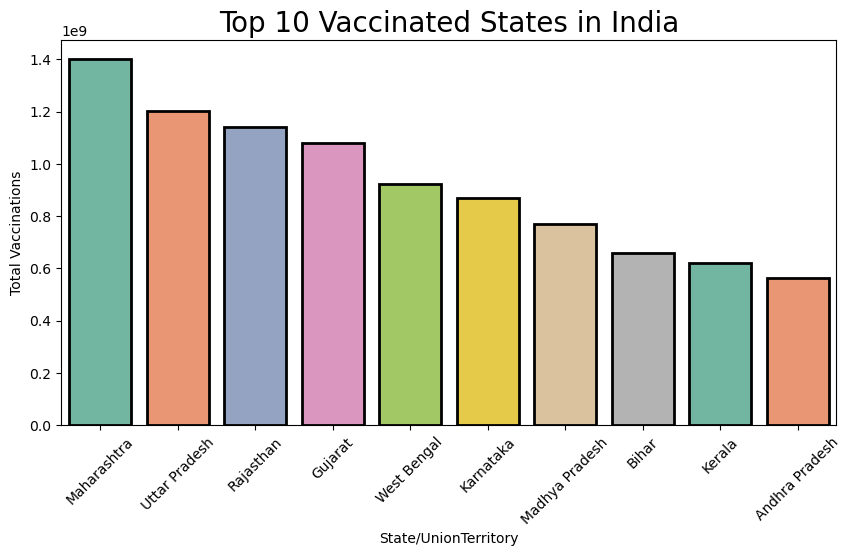

```python
fig2 = plt.figure(figsize = (10,5))
plt.title('Top 10 Vaccinated States in India', size = 20)
x = sns.barplot(data = max_vac.iloc[:10],
                y = max_vac.Total, x = max_vac.index, hue = max_vac.index,
                linewidth = 2, edgecolor = 'black',
               palette = 'Set2')
plt.xlabel('State/UnionTerritory')
plt.ylabel('Total Vaccinations')
plt.xticks(rotation = 45)
plt.show()
```

### Which states have administered the least number of vaccinations?

```python
# States with least number of vaccinations

least_vac = vaccine_df.groupby('State')['Total_Ind_Vacc'].sum().to_frame('Least_Total')
least_vac = least_vac.sort_values('Least_Total', ascending = True).iloc[:10]
least_vac
```

| State | Least_Total |
| --- | --- |
| Lakshadweep | 2124715.0 |
| Andaman and Nicobar Islands | 8102125.0 |
| Ladakh | 9466289.0 |
| Dadra and Nagar Haveli and Daman and Diu | 11358600.0 |
| Sikkim | 16136752.0 |
| Nagaland | 17624495.0 |
| Puducherry | 17760652.0 |
| Chandigarh | 19731496.0 |
| Mizoram | 20572453.0 |
| Arunachal Pradesh | 21081557.0 |

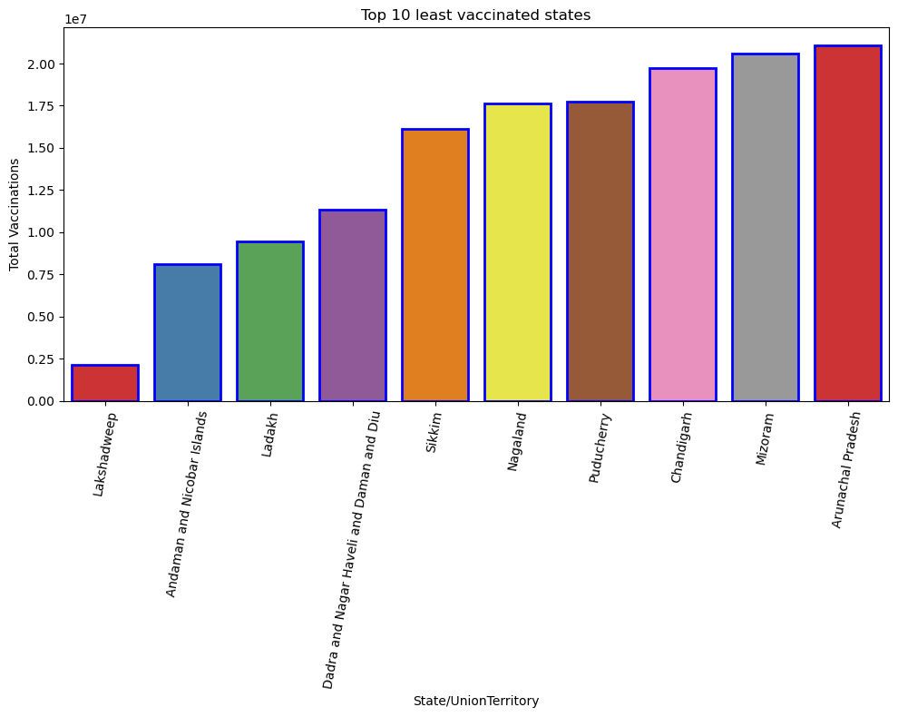

```python
fig3 = plt.figure(figsize = (10,8))
plt.title('Top 10 least vaccinated states')
sns.barplot(data = least_vac.iloc[:10], y = least_vac.Least_Total, x = least_vac.index, hue = least_vac.index,
            linewidth = 2, edgecolor = 'blue', palette = 'Set1')
plt.xlabel('State/UnionTerritory')
plt.ylabel('Total Vaccinations')
plt.xticks(rotation = 80)
plt.tight_layout()
plt.show()
```

### How did vaccinations impact active cases over time? (Correlation between increasing vaccines and decreasing active cases — combine both datasets)

```python
vaccine_df = vaccine_df.rename(columns = {'Total Doses Administered' : 'Total_Doses_Admin'})
```

```python
# Convert date columns to datetime format
vaccine_df['Vaccination_Date'] = pd.to_datetime(vaccine_df['Vaccination_Date'], dayfirst=True)
covid_df['Date'] = pd.to_datetime(covid_df['Date'])


# Group vaccination data by date
daily_vaccination = vaccine_df.groupby('Vaccination_Date')['Total_Doses_Admin'].sum().reset_index()

# Group COVID data by date (sum across states)
daily_cases = covid_df.groupby('Date')['Active_Cases'].sum().reset_index()

# Rename columns to match
daily_vaccination.rename(columns={'Vaccination_Date': 'Date'}, inplace=True)

print(daily_cases)
print(daily_vaccination)
```

```
          Date  Active_Cases
0   2020-01-30             1
1   2020-01-31             1
2   2020-02-01             2
3   2020-02-02             3
4   2020-02-03             3
..         ...           ...
471 2021-05-15       4206216
472 2021-05-16       4159026
473 2021-05-17       4065777
474 2021-05-18       3911203
475 2021-05-19       3793215

[476 rows x 2 columns]
          Date  Total_Doses_Admin
0   2021-01-16            48276.0
1   2021-01-17            58604.0
2   2021-01-18            99449.0
3   2021-01-19           195525.0
4   2021-01-20           251280.0
..         ...                ...
208 2021-08-12                0.0
209 2021-08-13                0.0
210 2021-08-14                0.0
211 2021-08-15                0.0
212 2021-08-16                0.0

[213 rows x 2 columns]
```

```python
# Merge both datasets on Date
merged_df = pd.merge(daily_vaccination, daily_cases, on='Date', how='inner')

# Sort by date
merged_df = merged_df.sort_values('Date')
merged_df
```

|  | Date | Total_Doses_Admin | Active_Cases |
| --- | --- | --- | --- |
| 0 | 2021-01-16 | 48276.0 | 515219 |
| 1 | 2021-01-17 | 58604.0 | 513374 |
| 2 | 2021-01-18 | 99449.0 | 512850 |
| 3 | 2021-01-19 | 195525.0 | 505640 |
| 4 | 2021-01-20 | 251280.0 | 502637 |
| ... | ... | ... | ... |
| 119 | 2021-05-15 | 181544536.0 | 4206216 |
| 120 | 2021-05-16 | 182251006.0 | 4159026 |
| 121 | 2021-05-17 | 183817204.0 | 4065777 |
| 122 | 2021-05-18 | 185191602.0 | 3911203 |
| 123 | 2021-05-19 | 186410600.0 | 3793215 |

124 rows × 3 columns

```python
# Compute daily new vaccinations
merged_df['Daily Vaccinations'] = merged_df['Total_Doses_Admin'].diff().fillna(0)

# Compute daily change in active cases
merged_df['Daily Change in Active Cases'] = merged_df['Active_Cases'].diff().fillna(0)

merged_df
```

|  | Date | Total_Doses_Admin | Active_Cases | Daily Vaccinations | Daily Change in Active Cases |
| --- | --- | --- | --- | --- | --- |
| 0 | 2021-01-16 | 48276.0 | 515219 | 0.0 | 0 |
| 1 | 2021-01-17 | 58604.0 | 513374 | 10328.0 | -1845 |
| 2 | 2021-01-18 | 99449.0 | 512850 | 40845.0 | -524 |
| 3 | 2021-01-19 | 195525.0 | 505640 | 96076.0 | -7210 |
| 4 | 2021-01-20 | 251280.0 | 502637 | 55755.0 | -3003 |
| ... | ... | ... | ... | ... | ... |
| 119 | 2021-05-15 | 181544536.0 | 4206216 | 1898123.0 | -23311 |
| 120 | 2021-05-16 | 182251006.0 | 4159026 | 706470.0 | -47190 |
| 121 | 2021-05-17 | 183817204.0 | 4065777 | 1566198.0 | -93249 |
| 122 | 2021-05-18 | 185191602.0 | 3911203 | 1374398.0 | -154574 |
| 123 | 2021-05-19 | 186410600.0 | 3793215 | 1218998.0 | -117988 |

124 rows × 5 columns

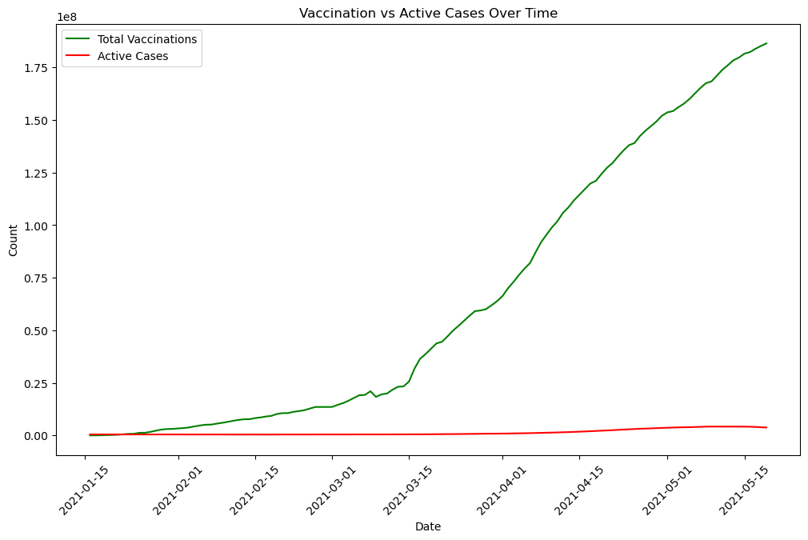

```python
plt.figure(figsize=(12, 7))

# Plot vaccinations
sns.lineplot(data=merged_df, x='Date', y='Total_Doses_Admin', label='Total Vaccinations', color='green')

# Plot active cases
sns.lineplot(data=merged_df, x='Date', y='Active_Cases', label='Active Cases', color='red')

plt.title('Vaccination vs Active Cases Over Time')
plt.xlabel('Date')
plt.ylabel('Count')
plt.legend()
plt.xticks(rotation=45)
plt.show()
```

[figure not shown]

```python
plt.figure(figsize=(14, 7))

# Plot daily vaccinations
sns.lineplot(data=merged_df, x='Date', y='Daily Vaccinations', label='Daily Vaccinations', color='green')

# Plot active cases
sns.lineplot(data=merged_df, x='Date', y='Daily Change in Active Cases', label='Daily Change in Active Cases', color='red')

plt.axvline(pd.to_datetime('2021-05-01'), color='blue', linestyle='--', label='Peak Vaccination Start')
plt.axvline(pd.to_datetime('2021-06-01'), color='purple', linestyle='--', label='Drop in Cases')

plt.title('Active Cases vs. Vaccinations Over Time')
plt.xlabel('Date')
plt.ylabel('Count')
plt.legend()
plt.xticks(rotation=45)
plt.show()
```

```python
covid_df.columns
```

```
Index(['Date', 'State/UnionTerritory', 'Cured', 'Deaths', 'Confirmed',
       'Active_Cases'],
      dtype='object')
```

```python
vaccine_df.columns
```

```
Index(['Vaccination_Date', 'State', 'Total_Doses_Admin', 'Sessions', ' Sites ',
       'First Dose Administered', 'Second Dose Administered',
       'Male (Doses Administered)', 'Female (Doses Administered)',
       'Transgender (Doses Administered)', ' Covaxin (Doses Administered)',
       'CoviShield (Doses Administered)', 'Sputnik V (Doses Administered)',
       'AEFI', '18-44 Years (Doses Administered)',
       '45-60 Years (Doses Administered)', '60+ Years (Doses Administered)',
       '18-44 Years(Individuals Vaccinated)',
       '45-60 Years(Individuals Vaccinated)',
       '60+ Years(Individuals Vaccinated)', 'Male(Individuals Vaccinated)',
       'Female(Individuals Vaccinated)', 'Transgender(Individuals Vaccinated)',
       'Total_Ind_Vacc'],
      dtype='object')
```

### Is there a delayed effect of vaccinations on active cases and deaths?

```python
# Aggregate daily confirmed cases and deaths
covid_summary = covid_df.groupby('Date')[['Confirmed', 'Cured', 'Deaths']].sum().reset_index()
covid_summary['Active_Cases'] = covid_summary['Confirmed'] - (covid_summary['Cured'] + covid_summary['Deaths'])

# Aggregate daily vaccinations
vaccine_summary = vaccine_df.groupby('Vaccination_Date')[['Total_Doses_Admin']].sum().reset_index()
vaccine_summary.rename(columns={'Vaccination_Date': 'Date'}, inplace=True)
```

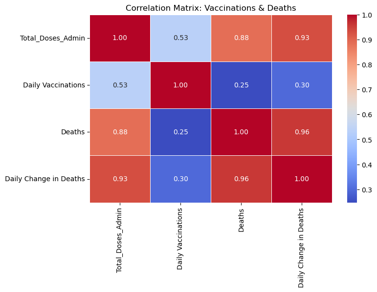

```python
# Merge both datasets
merged_df = pd.merge(covid_summary, vaccine_summary, on='Date', how='inner')

# Compute daily changes
merged_df['Daily Vaccinations'] = merged_df['Total_Doses_Admin'].diff().fillna(0)
merged_df['Daily Change in Deaths'] = merged_df['Deaths'].diff().fillna(0)

# Compute correlation matrix
correlation_deaths = merged_df[['Total_Doses_Admin', 'Daily Vaccinations', 'Deaths', 'Daily Change in Deaths']].corr()

# Plot correlation heatmap
plt.figure(figsize=(8,5))
sns.heatmap(correlation_deaths, annot=True, cmap='coolwarm', fmt=".2f", linewidths=0.5)

plt.title("Correlation Matrix: Vaccinations & Deaths")
plt.show()
```

```python
merged_df['Vaccinations_Lagged_14'] = merged_df['Daily Vaccinations'].shift(14)
merged_df['Vaccinations_Lagged_28'] = merged_df['Daily Vaccinations'].shift(28)

correlation_lagged_deaths = merged_df[['Vaccinations_Lagged_14', 'Vaccinations_Lagged_28', 'Daily Change in Deaths']].corr()
print(correlation_lagged_deaths)
```

```
                        Vaccinations_Lagged_14  Vaccinations_Lagged_28  \
Vaccinations_Lagged_14                1.000000                0.489184
Vaccinations_Lagged_28                0.489184                1.000000
Daily Change in Deaths                0.538232                0.735376

                        Daily Change in Deaths
Vaccinations_Lagged_14                0.538232
Vaccinations_Lagged_28                0.735376
Daily Change in Deaths                1.000000
```

### Which age group is most vaccinated across states?

```python
# Selecting relevant columns and grouping by State
age_vaccine_data = vaccine_df.groupby("State")[
    ["18-44 Years(Individuals Vaccinated)", "45-60 Years(Individuals Vaccinated)", "60+ Years(Individuals Vaccinated)"]
].sum().reset_index()

# Melting the dataframe for better visualization
age_vaccine_data_melted = age_vaccine_data.melt(id_vars=["State"],
                                                 var_name="Age Group",
                                                 value_name="Total Vaccinated")

# Creating an interactive bar chart using Plotly
fig = px.bar(age_vaccine_data_melted,
             x="State",
             y="Total Vaccinated",
             color="Age Group",
             barmode="group",
             title="Vaccination Distribution Across Age Groups by State",
             labels={"Total Vaccinated": "Total Individuals Vaccinated"},
             height=700, width=1000)

# Show the figure
fig.show()
```

[interactive chart not shown]

- The 18-44 Years age group (represented in blue) appears to have the highest number of vaccinated individuals in most states.
- The 45-60 Years age group (red) follows next in terms of total vaccinated individuals.
- The 60+ Years age group (green) has the lowest number of vaccinations across most states.

### Which vaccine type is most widely administered in India and in which states?

```python
vaccine_df = vaccine_df.rename(columns = {' Covaxin (Doses Administered)' : 'Covaxin', 'CoviShield (Doses Administered)':'Covishield',
                                          'Sputnik V (Doses Administered)' : 'Sputnik V'})
vaccine_df.columns
```

```
Index(['Vaccination_Date', 'State', 'Total_Doses_Admin', 'Sessions', ' Sites ',
       'First Dose Administered', 'Second Dose Administered',
       'Male (Doses Administered)', 'Female (Doses Administered)',
       'Transgender (Doses Administered)', 'Covaxin', 'Covishield',
       'Sputnik V', 'AEFI', '18-44 Years (Doses Administered)',
       '45-60 Years (Doses Administered)', '60+ Years (Doses Administered)',
       '18-44 Years(Individuals Vaccinated)',
       '45-60 Years(Individuals Vaccinated)',
       '60+ Years(Individuals Vaccinated)', 'Male(Individuals Vaccinated)',
       'Female(Individuals Vaccinated)', 'Transgender(Individuals Vaccinated)',
       'Total_Ind_Vacc'],
      dtype='object')
```

```python
# Melt the data
vaccine_distribution_melted = vaccine_distribution.melt(
    id_vars=['State'],
    var_name='Vaccine Type',
    value_name='Total Doses Administered'
)
# Remove 'India' from the dataset after melting (Cleaning is required as 'India' is not a state)
vaccine_distribution_melted = vaccine_distribution_melted[vaccine_distribution_melted['State'] != 'India']

fig = px.treemap(
    vaccine_distribution_melted,
    path=['State', 'Vaccine Type'],
    values='Total Doses Administered',
    title='Treemap of Vaccine Distribution Across States'
)


fig.show()
```

[output not shown]

[interactive chart not shown]

- The treemap visualization provides an insightful representation of vaccine distribution across various states in India.
- Maharashtra, Uttar Pradesh, Gujarat, and West Bengal are among the top states with the highest number of administered vaccine doses, with Covishield being the most widely used vaccine type across all states.
- While Covaxin is present in most states, it constitutes a smaller share of total vaccinations.
- The relative sizes of the blocks highlight the scale of vaccination efforts, making it evident which states have contributed the most to the nationwide vaccination drive.

#### Line chart for the above visualization

```python
fig = px.line(
    vaccine_distribution_melted,
    x="State",
    y="Total Doses Administered",
    color="Vaccine Type",
    title="Vaccine Administration Trends Across States",
    labels={"Total Doses Administered": "Total Doses"},
)

# Updating layout for better readability
fig.update_layout(
    xaxis_title="State",
    yaxis_title="Total Doses Administered",
    legend_title="Vaccine Type",
    xaxis=dict(showgrid=False),
    yaxis=dict(showgrid=True),
    template="plotly_white"
)

fig.show()
```

[interactive chart not shown]

- Covishield is the most widely administered vaccine across India, as evident from both the treemap and the line chart.
- States with the highest administration of Covishield: Maharashtra, Uttar Pradesh, Gujarat, Rajasthan, and West Bengal are among the top states with significant Covishield vaccinations.
- Covaxin, while administered, has a smaller share compared to Covishield across most states.

### Visulaize the statewise proportion of active cases and cured cases.

```python
statewise_cases = covid_df.groupby('State/UnionTerritory')[['Active_Cases', 'Cured']].sum().reset_index()

# Melt the dataframe for visualization
statewise_cases_melted = statewise_cases.melt(
    id_vars=['State/UnionTerritory'], var_name='Case Type', value_name='Total Cases'
)

# Create a stacked bar chart
fig = px.bar(
    statewise_cases_melted,
    x='State/UnionTerritory', y='Total Cases',
    color='Case Type',
    title='State-wise Proportion of Active vs. Cured Cases',
    labels={'Total Cases': 'Total Count'},
    barmode='relative'  # Makes it a stacked bar chart
)

# Show the plot
fig.show()
```

[interactive chart not shown]

- The state-wise proportion of active vs. cured cases indicates a significant variation in COVID-19 recovery trends across different states.
- Most states exhibit a higher proportion of cured cases (shown in red) compared to active cases (shown in blue), suggesting effective recovery efforts.
- However, a few states, such as Maharashtra, Kerala, and Karnataka, show notable active case proportions, indicating ongoing transmission or delayed recovery rates.
- This visualization highlights the effectiveness of healthcare responses across states and identifies areas where further interventions may be required.

### Which states have the highest recovery rates in India?

```python
# Compute Recovery Rate
statewise['Recovery_Rate'] = (statewise['Cured'] / statewise['Confirmed']) * 100

# Sort states by highest Recovery Rate
top_states = statewise.sort_values(by='Recovery_Rate', ascending=False).head(15)  # Top 15 states

# Reset index for visualization
top_states = top_states.reset_index()

# Sunburst Chart with increased size
fig = px.sunburst(
    top_states,
    path=['State/UnionTerritory'],  # Hierarchy with just states
    values='Recovery_Rate',
    title="Top States by Recovery Rate",
    color='Recovery_Rate',
    color_continuous_scale='greens',  # Green color scale for better representation
    labels={'Recovery_Rate': 'Recovery Rate (%)'},
    width=900,  # Increased width
    height=600  # Increased height
)

# Show the figure
fig.show()
```

[interactive chart not shown]

- The sunburst chart showcases the states with the highest recovery rates from COVID-19.
- Delhi, Andaman and Nicobar Islands, and Dadra and Nagar Haveli and Daman and Diu emerge as the top regions with recovery rates close to 95%, indicating a strong healthcare response and effective patient recovery.
- Other states such as Maharashtra, Uttar Pradesh, Telangana, Bihar, and Ladakh also demonstrate high recovery percentages, reflecting successful containment and treatment measures.
- The variation in recovery rates across states may be influenced by healthcare infrastructure, testing efficiency, and pandemic management strategies.

### Vissualize the State-wise heat map of total vaacinations

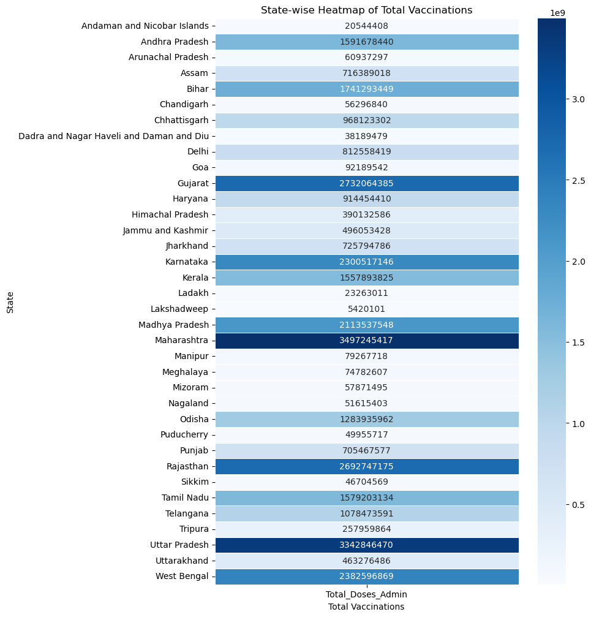

```python
# Aggregate total vaccinations for each state
state_vaccination_df = vaccine_df.groupby("State")[["Total_Doses_Admin"]].sum().reset_index()

state_vaccination_pivot = state_vaccination_df.pivot_table(
    values="Total_Doses_Admin", index="State"
)

# Plot the heatmap
plt.figure(figsize=(8, 12))  # Adjust size
sns.heatmap(state_vaccination_pivot, cmap="Blues", annot=True, fmt=".0f", linewidths=0.5)

plt.title("State-wise Heatmap of Total Vaccinations")
plt.xlabel("Total Vaccinations")
plt.ylabel("State")
plt.show()
```

- The heatmap of total vaccinations across states highlights significant variations in vaccine administration.
- Uttar Pradesh and Maharashtra emerge as the states with the highest number of total doses administered, followed by Gujarat, Rajasthan, and West Bengal.
- These states have played a crucial role in India's vaccination efforts, contributing to widespread immunization coverage.
- The data also indicates that states with higher population densities tend to have a larger number of administered doses, reflecting targeted vaccination campaigns and healthcare infrastructure availability.